# WGCNA analysis

# Get genes that was significant by adjusted p values

```r
sign_res <- which(res$padj <= 0.05)
head(sign_res)
```

```
[1]  1  7 15 35 37 44
```

```r
resOrdered
```

[output not shown]

Log fold change shrinkage for visualization and ranking

```r
resLFC <- lfcShrink(ddsTxi, res = res, type="ashr")
```

```
using 'ashr' for LFC shrinkage. If used in published research, please cite:
    Stephens, M. (2016) False discovery rates: a new deal. Biostatistics, 18:2.
    https://doi.org/10.1093/biostatistics/kxw041
```

```r
resLFC
```

```
log2 fold change (MMSE): group ASD vs Control
Wald test p-value: group ASD vs Control
DataFrame with 30232 rows and 5 columns
                  baseMean log2FoldChange     lfcSE      pvalue      padj
                 <numeric>      <numeric> <numeric>   <numeric> <numeric>
ENSG00000000003  415.24760      0.7132324  0.303646 0.000215353 0.0177926
ENSG00000000005    3.89464     -0.1879106  0.325503 0.162840948        NA
ENSG00000000419  420.19900     -0.2515645  0.184735 0.093879266 0.2412645
ENSG00000000457  189.27160     -0.0169692  0.153212 0.898871032 0.9418453
ENSG00000000460   49.25409     -0.1199872  0.172598 0.405598421 0.5847410
...                    ...            ...       ...         ...       ...
ENSG00000291300   8.390850      0.0704106  0.318652    0.558531  0.709344
ENSG00000291309   2.776164     -0.0432996  0.322955    0.700371        NA
ENSG00000291310   0.875125     -0.0172842  0.349435    0.788419        NA
ENSG00000291316 461.609441      0.1415305  0.154953    0.292886  0.477810
ENSG00000291317 315.855480      0.1213147  0.163652    0.384749  0.565430
```

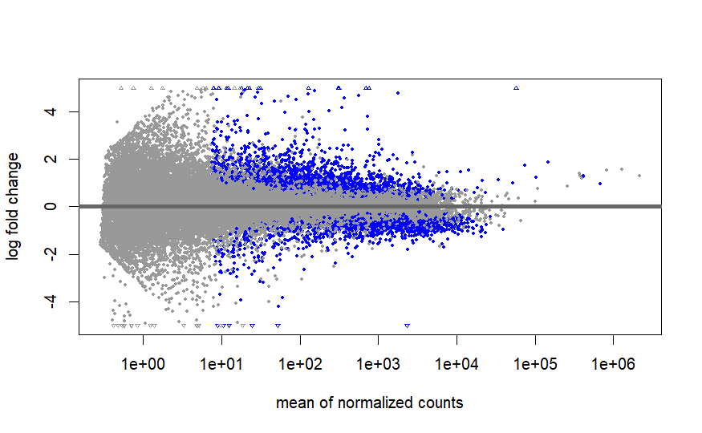

```r
plotMA(res, ylim=c(-5,5))
```

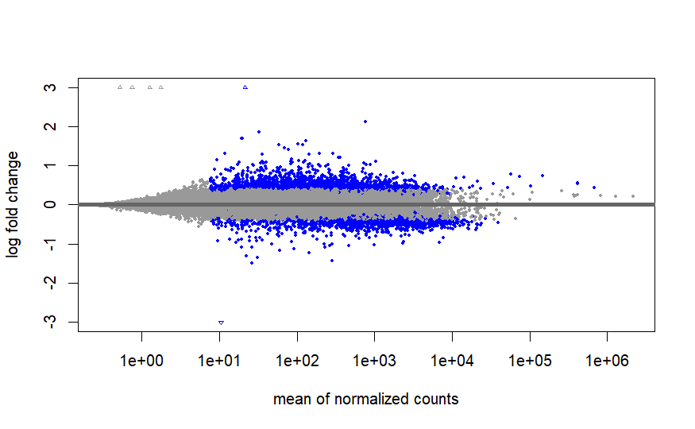

```r
plotMA(resLFC, ylim=c(-3,3))
```

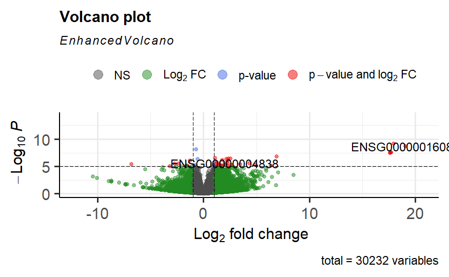

```r
library(EnhancedVolcano)
  EnhancedVolcano(res,
    lab = rownames(res),
    x = 'log2FoldChange',
    y = 'pvalue')
```

```r
library(WGCNA)
```

# We only need expression data here

## Suppose the gene expression starts at column n

## We need the data in the form of samples x gene counts

```r
# n= 3
datExpr=as.data.frame(t(data))
# We only use genes that expressed more than 10 counts from all samples
datExpr <- datExpr[,names(keep)]
datExpr
```

|  | ENSG00000000003 | ENSG00000000005 | ENSG00000000419 | ENSG00000000457 | ENSG00000000460 | ENSG00000000938 | ENSG00000000971 | ENSG00000001036 | ENSG00000001084 | ENSG00000001167 | ENSG00000001460 | ENSG00000001461 | ENSG00000001497 | ENSG00000001561 | ENSG00000001617 | ENSG00000001626 | ENSG00000001629 | ENSG00000001630 | ENSG00000001631 | ENSG00000002016 | ENSG00000002079 | ENSG00000002330 | ENSG00000002549 | ENSG00000002586 | ENSG00000002587 | ENSG00000002726 | ENSG00000002745 | ENSG00000002746 | ENSG00000002822 | … |
| --- | --- | --- | --- | --- | --- | --- | --- | --- | --- | --- | --- | --- | --- | --- | --- | --- | --- | --- | --- | --- | --- | --- | --- | --- | --- | --- | --- | --- | --- | --- |
| ASD_4231 | 576 | 8 | 531 | 209 | 59 | 45 | 92 | 386 | 1100 | 829 | 272 | 2133 | 396 | 1556 | 15 | 24 | 1754 | 2125 | 721 | 213 | 20 | 736 | 704 | 975 | 130 | 0 | 38 | 369 | 194 | … |
| ASD_4334 | 304 | 2 | 211 | 113 | 25 | 132 | 230 | 315 | 489 | 394 | 199 | 2104 | 505 | 514 | 110 | 8 | 884 | 1063 | 333 | 173 | 0 | 751 | 1362 | 1594 | 82 | 0 | 9 | 43 | 267 | … |
| ASD_5144 | 295 | 2 | 318 | 123 | 66 | 184 | 236 | 333 | 1091 | 632 | 219 | 2095 | 523 | 911 | 102 | 12 | 1782 | 1027 | 540 | 380 | 0 | 733 | 755 | 1575 | 80 | 0 | 8 | 217 | 124 | … |
| ASD_5308 | 367 | 5 | 670 | 263 | 52 | 71 | 231 | 434 | 1257 | 846 | 301 | 3342 | 926 | 1491 | 33 | 36 | 1957 | 2681 | 548 | 149 | 3 | 1279 | 836 | 776 | 134 | 0 | 9 | 218 | 498 | … |
| ASD_5454 | 306 | 0 | 163 | 95 | 16 | 87 | 363 | 246 | 360 | 354 | 249 | 1369 | 538 | 391 | 219 | 5 | 551 | 783 | 223 | 125 | 0 | 764 | 310 | 1100 | 55 | 0 | 2 | 158 | 244 | … |
| ASD_5565 | 294 | 0 | 157 | 136 | 35 | 70 | 220 | 225 | 518 | 478 | 231 | 2439 | 469 | 757 | 49 | 23 | 1075 | 1147 | 373 | 102 | 0 | 855 | 440 | 1289 | 95 | 0 | 5 | 206 | 298 | … |
| ASD_5841 | 1497 | 3 | 478 | 268 | 48 | 63 | 672 | 748 | 810 | 781 | 303 | 2520 | 649 | 1066 | 130 | 10 | 1595 | 2063 | 610 | 164 | 0 | 1255 | 758 | 1433 | 113 | 0 | 25 | 242 | 375 | … |
| Control_4337 | 335 | 8 | 560 | 301 | 69 | 53 | 257 | 435 | 1324 | 1000 | 352 | 3210 | 604 | 1237 | 38 | 10 | 1998 | 2887 | 908 | 166 | 0 | 1027 | 986 | 989 | 251 | 0 | 47 | 875 | 237 | … |
| Control_4925 | 208 | 5 | 465 | 240 | 55 | 29 | 69 | 377 | 1095 | 797 | 518 | 3796 | 882 | 1395 | 51 | 15 | 1565 | 2746 | 684 | 192 | 1 | 1397 | 556 | 548 | 155 | 0 | 71 | 1245 | 346 | … |
| Control_5170 | 368 | 9 | 576 | 284 | 64 | 45 | 171 | 431 | 1143 | 837 | 303 | 2961 | 624 | 1465 | 51 | 4 | 1916 | 2692 | 613 | 100 | 0 | 1080 | 893 | 1042 | 224 | 0 | 29 | 760 | 310 | … |

[output cut: 3 more lines]

```r
which(is.na(datExpr), arr.ind=TRUE)
```

```
     row col
```

# Make sure that the order of trait match from design table (trait table) and the gene expression data - If not, sort them in the same order

```r
trait_dat <- trait_dat  %>% column_to_rownames(var = 'library')
trait_dat <- trait_dat[rownames(datExpr),]
trait_dat
```

|  | Subject | group | Age | Sex | Race | RIN | PMI_hrs | Hemisphere | Epilepsy | Cause_of_Death | Measures |
| --- | --- | --- | --- | --- | --- | --- | --- | --- | --- | --- | --- |
| ASD_4231 | 4231 | ASD | 8 | Male | NA | 7.1 | 12 | Left | NA | unknown | RNA,Western |
| ASD_4334 | 4334 | ASD | 8 | Male | Hispanic | 7.1 | 27 | Left | No | natural | RNA,Western,Microscopy |
| ASD_5144 | 5144 | ASD | 7 | Male | White | 7.7 | 3 | Left | No | natural | RNA,Western,Microscopy |
| ASD_5308 | 5308 | ASD | 4 | Male | White | 6.0 | 21 | Left | No | accidental | RNA,Western,Microscopy |
| ASD_5454 | 5454 | ASD | 11 | Male | NA | 4.8 | 20 | Left | NA | unknown | RNA,Western,Microscopy |
| ASD_5565 | 5565 | ASD | 12 | Male | Black | 8.3 | 22 | Left | Yes | natural | RNA,Western,Microscopy |
| ASD_5841 | 5841 | ASD | 12 | Male | NA | 6.5 | 15 | Left | NA | unknown | RNA,Western,Microscopy |
| Control_4337 | 4337 | Control | 8 | Male | Black | 8.4 | 16 | Left | No | natural | RNA,Western,Microscopy |
| Control_4925 | 4925 | Control | 13 | Male | Black | 6.8 | 16 | Left | No | natural | RNA,Western,Microscopy |
| Control_5170 | 5170 | Control | 13 | Male | Black | 6.8 | 20 | Left | No | unknown | RNA,Western,Microscopy |

[output cut: 3 more lines]

# Double check that the names are the same order from both data

```r
sum(rownames(datExpr) != rownames(trait_dat)) == 0
```

```
[1] TRUE
```

# Constructing a Sample Network for Outlier Detection

## Find the soft threshold for the sample network

```r
powers=c(c(1:10),seq(from=12,to=20,by=2))
# choose power based on SFT criterion
sft=pickSoftThreshold(as.matrix(t(datExpr),powerVector=powers))
```

| Power | SFT.R.sq | slope | truncated.R.sq | mean.k. | median.k. | max.k. |
| --- | --- | --- | --- | --- | --- | --- |
| 1 | 0.03420 | 191.00 | -0.236 | 11.50 | 11.50 | 11.70 |
| 2 | 0.03130 | 85.50 | -0.221 | 11.00 | 11.10 | 11.40 |
| 3 | 0.03130 | 57.60 | -0.221 | 10.60 | 10.60 | 11.10 |
| 4 | 0.00897 | -19.50 | -0.274 | 10.20 | 10.20 | 10.90 |
| 5 | 0.00897 | -15.80 | -0.274 | 9.79 | 9.83 | 10.60 |
| 6 | 0.00896 | -13.30 | -0.274 | 9.42 | 9.45 | 10.30 |
| 7 | 0.00894 | -11.50 | -0.274 | 9.07 | 9.08 | 10.10 |
| 8 | 0.00772 | -9.42 | -0.276 | 8.73 | 8.73 | 9.83 |
| 9 | 0.00758 | -8.38 | -0.276 | 8.41 | 8.39 | 9.59 |
| 10 | 0.00743 | -7.54 | -0.276 | 8.11 | 8.07 | 9.35 |

[output cut: 5 more lines]

```r
# Plot the results:
par(mfrow=c(1,2))
# SFT index as a function of different powers
plot(sft$fitIndices[,1],
-sign(sft$fitIndices[,3])*sft$fitIndices[,2],
xlab="Soft Threshold (power)",ylab="Scale Free Topology
Model Fit,
signed Rˆ2",type="n",main=paste("Scale independence"))
text(sft$fitIndices[,1],
-sign(sft$fitIndices[,3])*sft$fitIndices[,2],
labels=powers,col="red")
```

```r
# this line corresponds to using an Rˆ2 cut-off of h
abline(h=0.90,col="red")
# Mean connectivity as a function of different powers
plot(sft$fitIndices[,1],sft$fitIndices[,5],type="n",
xlab="Soft Threshold (power)",ylab="Mean Connectivity",
main=paste("Mean connectivity"))
```

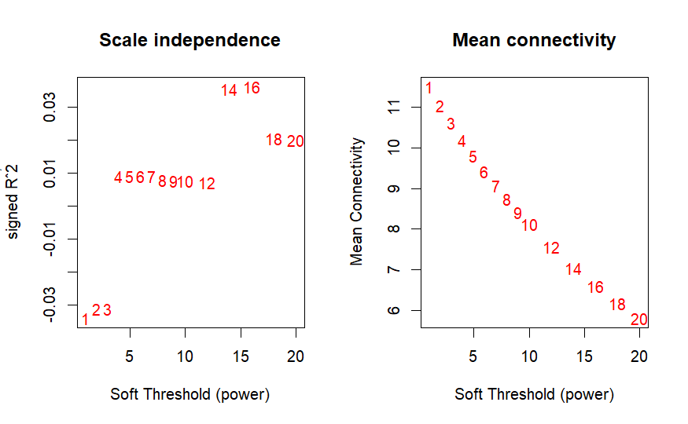

```r
text(sft$fitIndices[,1],sft$fitIndices[,5],labels=powers,
col="red")
```

# Convert all the non-numeric traits to factor

```r
trait_dat_orig = trait_dat

trait_dat_color <- trait_dat[, c("group","Age","PMI_hrs")]

for (n in c(1:length(colnames(trait_dat_color)))){

  trait_dat_color[,n] = as.numeric(factor(trait_dat_color[,n], level =trait_dat_color[,n], labels = rank(factor(trait_dat_color[,n]))))

}
trait_dat_color
```

|  | group | Age | PMI_hrs |
| --- | --- | --- | --- |
| ASD_4231 | 1 | 1 | 1 |
| ASD_4334 | 1 | 1 | 2 |
| ASD_5144 | 1 | 2 | 3 |
| ASD_5308 | 1 | 3 | 4 |
| ASD_5454 | 1 | 4 | 5 |
| ASD_5565 | 1 | 5 | 6 |
| ASD_5841 | 1 | 5 | 7 |
| Control_4337 | 2 | 1 | 8 |
| Control_4925 | 2 | 6 | 8 |
| Control_5170 | 2 | 6 | 5 |

[output cut: 3 more lines]

[output not shown]

[output cut: 3 more lines]

# After we check data outlier of sample, we can do Co-Expression Modules

## Again, we find the soft threshold for the weight similarity matrix

### This will take long time to run, depending on the sample size

```r
datExpr_filtered <- datExpr
powers=c(c(1:10),seq(from=12,to=20,by=2))
# choose power based on SFT criterion
sft=pickSoftThreshold(as.matrix(datExpr_filtered),powerVector=powers)
```

| Power | SFT.R.sq | slope | truncated.R.sq | mean.k. | median.k. | max.k. |
| --- | --- | --- | --- | --- | --- | --- |
| 1 | 0.118 | 2.900 | 0.180 | 6770 | 8140.00 | 17000 |
| 2 | 0.289 | -0.614 | 0.121 | 3100 | 2830.00 | 11000 |
| 3 | 0.661 | -0.353 | 0.751 | 1790 | 1280.00 | 8220 |
| 4 | 0.887 | -0.894 | 0.855 | 1180 | 650.00 | 6670 |
| 5 | 0.919 | -1.030 | 0.899 | 855 | 370.00 | 5660 |
| 6 | 0.930 | -1.080 | 0.914 | 656 | 225.00 | 4940 |
| 7 | 0.934 | -1.100 | 0.916 | 524 | 143.00 | 4390 |
| 8 | 0.932 | -1.120 | 0.913 | 432 | 94.30 | 3950 |
| 9 | 0.931 | -1.130 | 0.914 | 364 | 64.90 | 3590 |
| 10 | 0.929 | -1.130 | 0.917 | 313 | 45.10 | 3280 |

[output cut: 5 more lines]

```r
# Plot the results:
par(mfrow=c(1,2))
# SFT index as a function of different powers
plot(sft$fitIndices[,1],
-sign(sft$fitIndices[,3])*sft$fitIndices[,2],
xlab="Soft Threshold (power)",ylab="Scale Free Topology
Model Fit,
signed Rˆ2",type="n",main=paste("Scale independence"))
text(sft$fitIndices[,1],
-sign(sft$fitIndices[,3])*sft$fitIndices[,2],
labels=powers,col="red")
```

```r
# this line corresponds to using an Rˆ2 cut-off of h
abline(h=0.90,col="red")
# Mean connectivity as a function of different powers
plot(sft$fitIndices[,1],sft$fitIndices[,5],type="n",
xlab="Soft Threshold (power)",ylab="Mean Connectivity",
main=paste("Mean connectivity"))
```

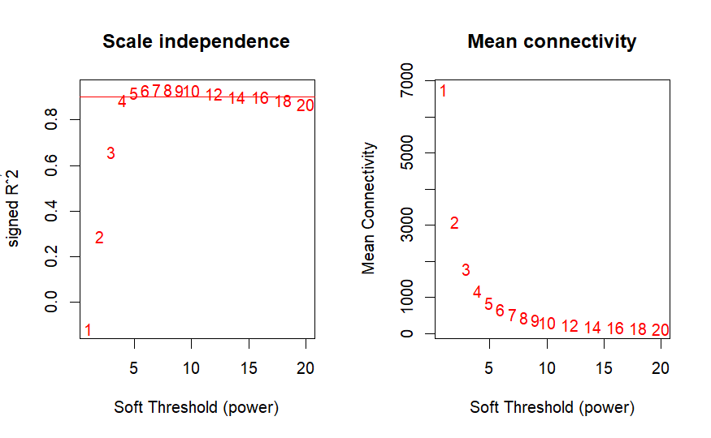

```r
text(sft$fitIndices[,1],sft$fitIndices[,5],labels=powers,
col="red")
```

```r
t <- colSums(datExpr)
t <- which(t > 5) # I choose 60 just for demo to save time and memory, 10 is more common
datExpr_filtered <- datExpr[,t]
```

```r
library(flashClust)
```

```r
# We now calculate the weighted adjacency matrix, using the power:
power = 4
# We use bicor: Biweight Midcorrelation in WGCNA
A = adjacency(datExpr_filtered, power = power,corFnc="bicor")
#define a dissimilarity based on the topological overlap
dissTOM =TOMdist(A)
```

```
..connectivity..
..matrix multiplication (system BLAS)..
..normalization..
..done.
```

```r
#hierarchical clustering
geneTree = flashClust(as.dist(dissTOM),method="average")
```

```r
# here we define the modules by cutting branches
moduleLabelsManual=cutreeDynamic(dendro=geneTree,distM=dissTOM,
method="hybrid",deepSplit=2,pamRespectsDendro=F,
minClusterSize=50)
```

```
 ..cutHeight not given, setting it to 0.969  ===>  99% of the (truncated) height range in dendro.
 ..done.
```

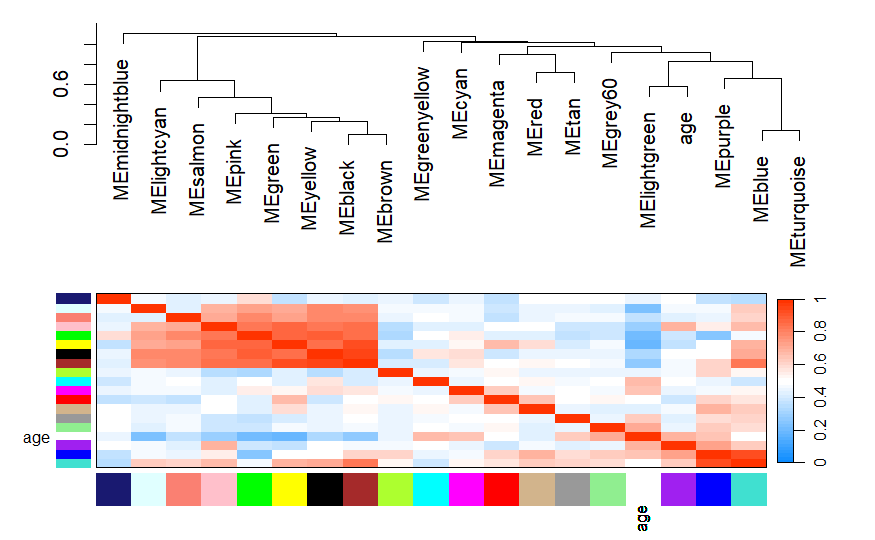

```r
# Calculate eigengenes
moduleColorsManual <- labels2colors(moduleLabelsManual)
MEList=moduleEigengenes(datExpr_filtered,colors=moduleColorsManual)
MEs = MEList$eigengenes
age = trait_dat$Age
# Add the weight to existing module eigengenes
MET=orderMEs(cbind(MEs,age))
# Plot the relationships among the eigengenes and the trait
plotEigengeneNetworks(MET,"",marDendro=c(0,4,1,2),
marHeatmap=c(3,4,1,2),cex.lab=0.8,xLabelsAngle=90)
```

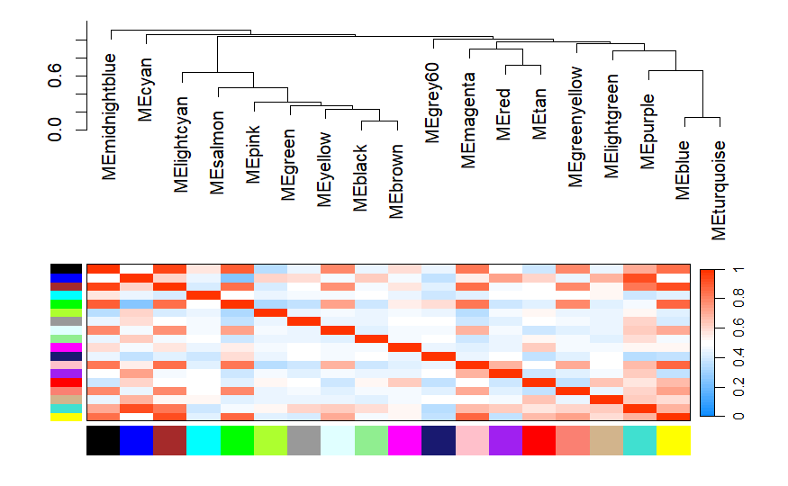

```r
plotEigengeneNetworks(MEs,"",marDendro=c(0,4,1,2),plotHeatmaps = TRUE,
marHeatmap=c(3,4,1,2),cex.lab=0.8,xLabelsAngle=90)
```

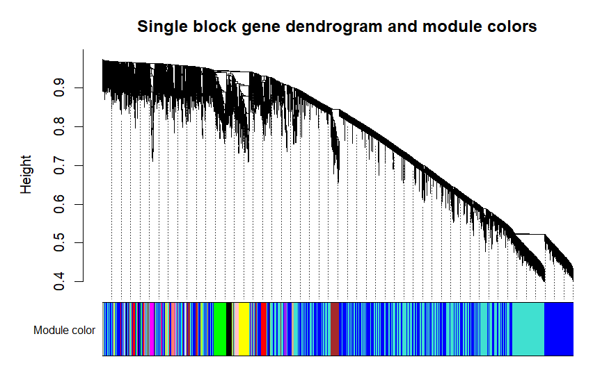

```r
sizeGrWindow(12,9)
plotDendroAndColors(geneTree,
moduleColorsManual,
"Module color",
main = "Single block gene dendrogram and module colors",
dendroLabels = FALSE, hang = 0.03,
addGuide = TRUE, guideHang = 0.05)
```

# Since each variable may have many levels of catagory, we may want to make pairwise comparision between each pair and we want to look at all the possible pairs

```r
trait_dat_orig
```

|  | Subject | group | Age | Sex | Race | RIN | PMI_hrs | Hemisphere | Epilepsy | Cause_of_Death | Measures |
| --- | --- | --- | --- | --- | --- | --- | --- | --- | --- | --- | --- |
| ASD_4231 | 4231 | ASD | 8 | Male | NA | 7.1 | 12 | Left | NA | unknown | RNA,Western |
| ASD_4334 | 4334 | ASD | 8 | Male | Hispanic | 7.1 | 27 | Left | No | natural | RNA,Western,Microscopy |
| ASD_5144 | 5144 | ASD | 7 | Male | White | 7.7 | 3 | Left | No | natural | RNA,Western,Microscopy |
| ASD_5308 | 5308 | ASD | 4 | Male | White | 6.0 | 21 | Left | No | accidental | RNA,Western,Microscopy |
| ASD_5454 | 5454 | ASD | 11 | Male | NA | 4.8 | 20 | Left | NA | unknown | RNA,Western,Microscopy |
| ASD_5565 | 5565 | ASD | 12 | Male | Black | 8.3 | 22 | Left | Yes | natural | RNA,Western,Microscopy |
| ASD_5841 | 5841 | ASD | 12 | Male | NA | 6.5 | 15 | Left | NA | unknown | RNA,Western,Microscopy |
| Control_4337 | 4337 | Control | 8 | Male | Black | 8.4 | 16 | Left | No | natural | RNA,Western,Microscopy |
| Control_4925 | 4925 | Control | 13 | Male | Black | 6.8 | 16 | Left | No | natural | RNA,Western,Microscopy |
| Control_5170 | 5170 | Control | 13 | Male | Black | 6.8 | 20 | Left | No | unknown | RNA,Western,Microscopy |

[output cut: 3 more lines]

## Also need to get position of continuous variables you want to study, e.g. pmd, age

```r
pos <- c(2,4)
pos_con <- c(3,6,7)
binary_cat <- binarizeCategoricalColumns.pairwise(trait_dat_orig[,pos])
binary_cat <- data.frame(trait_dat_orig[,pos_con], binary_cat)
binary_cat
```

|  | Age | RIN | PMI_hrs | group.ASD.vs.Control |
| --- | --- | --- | --- | --- |
| ASD_4231 | 8 | 7.1 | 12 | 1 |
| ASD_4334 | 8 | 7.1 | 27 | 1 |
| ASD_5144 | 7 | 7.7 | 3 | 1 |
| ASD_5308 | 4 | 6.0 | 21 | 1 |
| ASD_5454 | 11 | 4.8 | 20 | 1 |
| ASD_5565 | 12 | 8.3 | 22 | 1 |
| ASD_5841 | 12 | 6.5 | 15 | 1 |
| Control_4337 | 8 | 8.4 | 16 | 0 |
| Control_4925 | 13 | 6.8 | 16 | 0 |
| Control_5170 | 13 | 6.8 | 20 | 0 |

[output cut: 3 more lines]

```r
# Choose a module assignment

# Define numbers of genes and samples
nGenes = ncol(datExpr_filtered)
nSamples = nrow(datExpr_filtered)
# Recalculate MEs with color labels
MEs0 = moduleEigengenes(datExpr_filtered,moduleColorsManual)$eigengenes
MEs = orderMEs(MEs0)
modTraitCor = cor(MEs, binary_cat, use = "p", method = 'spearman')
modTraitP = corPvalueStudent(modTraitCor, nSamples)
#Since we have a moderately large number of modules and traits,
#a suitable graphical representation will help in reading
#the table. We color code each association by the correlation value:
# Will display correlations and their p-values
textMatrix = paste(signif(modTraitCor, 2), "\n(",
signif(modTraitP, 1), ")", sep = "")
dim(textMatrix) = dim(modTraitCor)
# sizeGrWindow(9,19)
# par(mfrow = c(2,2))
# par(mar = c(60,0,0,0))
# Display the correlation values within a heatmap plot
# labeledHeatmap(Matrix = t(modTraitCor), yLabels = names(binary_cat),
# xLabels = names(MEs), xSymbols = names(MEs),
# colorLabels=FALSE,colors=blueWhiteRed (30),textMatrix=t(textMatrix),
# setStdMargins = TRUE, cex.text = 0.5, zlim = c(-1,1),keepLegendSpace=TRUE,xColorWidth = 0.5*strheight("M"),textAdj = c(0.3, 0.3),
# main = paste("Module-trait relationships"))
```

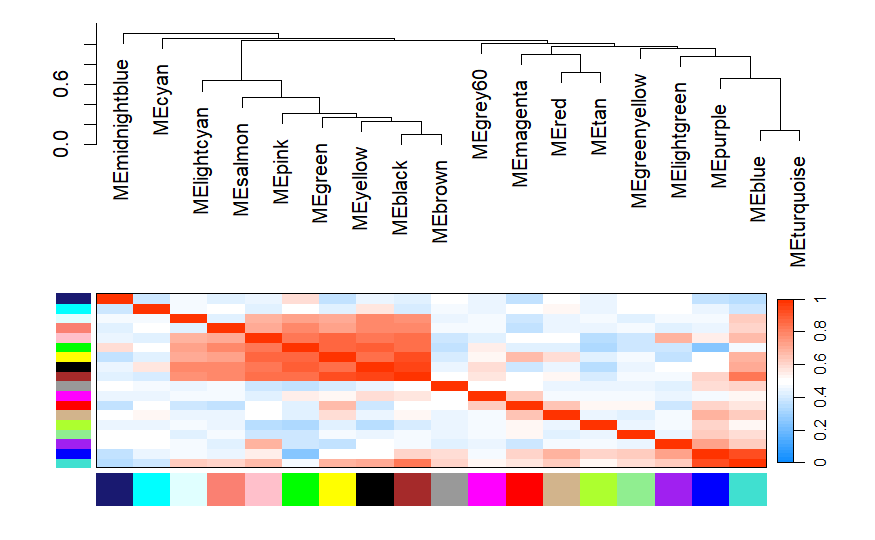

```r
plotEigengeneNetworks(MEs,"",marDendro=c(0,4,1,2),plotHeatmaps = TRUE,colorLabels=TRUE,
marHeatmap=c(3,4,1,2),cex.lab=0.8,xLabelsAngle=90)
```

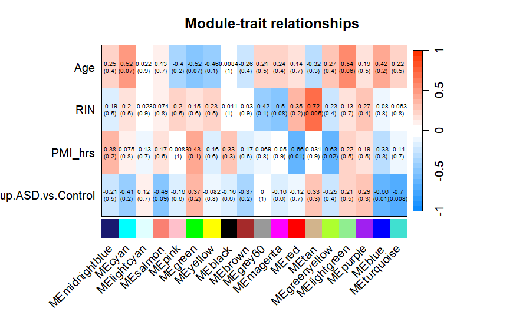

```r
labeledHeatmap(Matrix = t(modTraitCor[1:(nrow(modTraitCor)-1),]), yLabels = names(binary_cat),
xLabels = names(MEs)[1:(nrow(modTraitCor)-1)], xSymbols = names(MEs)[1:(nrow(modTraitCor)-1)],
colorLabels=FALSE,colors=blueWhiteRed (30),textMatrix=t(textMatrix[1:(nrow(modTraitCor)-1),]),
setStdMargins = TRUE, cex.text = 0.5, zlim = c(-1,1),
main = paste("Module-trait relationships"))
```

```r
# library(cowplot)
# plot_grid(p1, p2, align = 'v', rel_heights = c(1, 1),nrow = 2)
```

```r
# For the full dendrogram
library(plyr)
library(reshape2)
library(dplyr)
library(ggplot2)
library(ggdendro)
library(gridExtra)
library(dendextend)

set.seed(10)

# The source data
# mat <- t(MEs)

# sample_names <- colnames(mat)

# Obtain the dendrogram
# Obtain the dendrogram
# Need to remove the grey since those genes do not belong to any module
# dend <- as.dendrogram(hclust(dist(t(MEs[,1:(ncol(MEs)-1)]))))
# dend_data <- dendro_data(dend)

# Setup the data, so that the layout is inverted (this is more
# "clear" than simply using coord_flip())

# Use the dendrogram label data to position the gene labels
# mat <- t(MEs)

sample_names <-colnames(modTraitCor)

# Obtain the dendrogram
# Obtain the dendrogram
# Need to remove the grey since those genes do not belong to any module
dend <- as.dendrogram(hclust(dist(t(MEs[,1:(ncol(MEs)-1)]))))
dend_data <- dendro_data(dend)
segment_data <- with(
    segment(dend_data),
    data.frame(x = y, y = x, xend = yend, yend = xend))

modTraitCor[1:(nrow(modTraitCor)),]
```

```
                       Age         RIN      PMI_hrs group.ASD.vs.Control
MEmidnightblue  0.25251030 -0.18732853  0.380045651          -0.20619652
MEcyan          0.52466030  0.19834786  0.074899508          -0.41239305
MElightcyan     0.02244536 -0.02754831 -0.133154681           0.12371791
MEsalmon        0.12906082  0.07438045  0.174765518          -0.49487166
MEpink         -0.39559948  0.20110269 -0.008322168          -0.16495722
MEgreen        -0.52185463  0.14876090  0.432752712           0.37115374
MEyellow       -0.46293556  0.22865101 -0.158121183          -0.08247861
MEblack         0.00841701 -0.01101933  0.327338590          -0.16495722
MEbrown        -0.26373298 -0.03030315 -0.166443351          -0.37115374
MEgrey60        0.21323092 -0.42424403 -0.069351396           0.00000000
MEmagenta       0.24128762 -0.49862448 -0.049933005          -0.16495722
MEred           0.13747783  0.34710876 -0.662999348          -0.12371791
MEtan          -0.31704071  0.72176582  0.030514614           0.32991444
MEgreenyellow   0.26934432 -0.23140584 -0.626936622          -0.24743583
MElightgreen    0.53868865  0.13498674  0.221924468           0.20619652
MEpurple        0.19359123  0.26721864  0.194183909           0.28867513
MEblue          0.41523917 -0.07989011 -0.332886702          -0.65982888
MEturquoise     0.21603659 -0.06336112 -0.113736290          -0.70106818
MEgrey         -0.11503247 -0.31956044 -0.066577340          -0.20619652
```

```r
tmp <- modTraitP[1:(nrow(modTraitCor)),]
colnames(tmp) <- paste0("P_val_",colnames(tmp))

modTraitP = corPvalueStudent(modTraitCor, nSamples)

dat_heat <- cbind(modTraitCor[1:(nrow(modTraitCor)),],tmp)


gene_pos_table <- with(
    dend_data$labels,
    data.frame(y_center = x, module = as.character(label), height = 1))

# Table to position the samples
sample_pos_table <- data.frame(sample = sample_names) %>%
    mutate(x_center = c(1:length(colnames(modTraitCor))),
           width = 1)

# Limits for the vertical axes
gene_axis_limits <- with(
    gene_pos_table,
    c(min(y_center - 0.5 * height), max(y_center + 0.5 * height))
) + 0.1 * c(-1, 1) # extra spacing: 0.1

covariance <- colnames(modTraitCor)

covariance_pos_table <- data.frame(covariance = covariance) %>%
    mutate(x_center = c(1:dim(modTraitCor)[2]),
           width = 1)
# Neglecting the gap parameters
heatmap_data <- modTraitCor[1:(nrow(modTraitCor)),] %>% as.data.frame() %>% rownames_to_column(var = "module") %>%

    reshape2::melt(value.name = "cor", varnames = c("module")) %>%
    right_join(gene_pos_table[1:(nrow(gene_pos_table)),], by=
              "module") %>%
    left_join(covariance_pos_table, by = c("variable"="covariance"))
heatmap_data_Pvalue <- modTraitP[1:(nrow(modTraitP)),] %>% as.data.frame() %>% rownames_to_column(var = "module") %>%

    reshape2::melt(value.name = "cor", varnames = c("module")) %>%
    right_join(gene_pos_table[1:(nrow(gene_pos_table)),], by=
              "module") %>%
    left_join(covariance_pos_table, by = c("variable"="covariance"))
heatmap_data$cor_pvalue = paste0(round(heatmap_data$cor,3), "\n","(",round(heatmap_data_Pvalue$cor,3),")")
heatmap_data$cor <- heatmap_data_Pvalue$cor


color_bar <- heatmap_data %>% filter(variable == heatmap_data[1,2])
# color_bar$height = 1.5*color_bar$height
color_bar$color_order <- (str_remove(color_bar$module,"ME"))
plt_colorbar <- ggplot(color_bar,
                   aes(x = x_center, y = y_center,height = height, width = width)) +
    geom_tile(fill = color_bar$color_order) +scale_y_continuous(
                       limits = gene_axis_limits, position = "right",
                       expand = c(0, 0)) + theme(axis.title=element_blank(),plot.margin = unit(c(-1, -0.5, -1, -0.5), "cm"),
        axis.ticks=element_blank(),panel.background = element_blank(),
        axis.text=element_blank(),
        legend.position="none")   + coord_flip()


# Heatmap plot
plt_hmap <- ggplot(heatmap_data,
                   aes(x = x_center, y = y_center, fill = cor,
                       height = height, width = width)) +
    geom_tile() +
    scale_fill_gradient("Pvalue", high = "white", low = "red") +
    scale_x_continuous(breaks = sample_pos_table$x_center,
                       labels = covariance,
                       expand = c(0, 0)) +
    geom_text(aes(label = cor_pvalue), size = 3) +
    # For the y axis, alternatively set the labels as: gene_position_table$gene
    scale_y_continuous(breaks = gene_pos_table[, "y_center"],
                       labels = gene_pos_table$module,
                       limits = gene_axis_limits, position = "right",
                       expand = c(0, 0)) +
    labs(x = "Covariate", y = "")+

    theme(axis.text.x = element_text(size = rel(1), hjust = 0, angle = 45),
          # margin: top, right, bottom, and left
          plot.margin = unit(c(0.0, 0.2, 0.2, 0.7), "cm"),
          panel.grid.minor = element_blank(),legend.position="bottom") + coord_flip()
# Dendrogram plot
plt_dendr <- ggplot(segment_data) + ggtitle("ME dendrogram") +
    geom_segment(aes(x = x, y = y, xend = xend, yend = yend)) +
    # scale_x_reverse(expand = c(0, 0.5)) +
    scale_y_continuous(breaks = gene_pos_table$y_center,
                       labels = gene_pos_table$module,
                       limits = gene_axis_limits,
                       expand = c(0, 0)) +
    labs(x = "Distance", y = "", colour = "", size = "") +
    theme_bw() +
    theme(panel.grid.minor  = element_blank())+ coord_flip()+
    theme(axis.text.x = element_text(size = rel(1), hjust = 1, angle = 45),
          # margin: top, right, bottom, and left
          plot.margin = unit(c(1, 0.2, 0.2, -0.7), "cm"),
          panel.grid.minor = element_blank())

library(cowplot)
plot_grid(plt_dendr,plt_colorbar, plt_hmap, align = 'v', rel_heights = c(1, 1/12, 1),nrow = 3)


png(file="module_trait.png",
width=1900, height=1900, res=200)
```

[figure not shown]

```r
plot_grid(plt_dendr,plt_colorbar, plt_hmap, align = 'v', rel_heights = c(1, 1/12, 1),nrow = 3)
dev.off()
```

```r
mat <- t(MEs)

sample_names <-colnames(modTraitCor)

# Obtain the dendrogram
# Obtain the dendrogram
# Need to remove the grey since those genes do not belong to any module
dend <- as.dendrogram(hclust(dist(t(MEs[,1:(ncol(MEs)-1)]))))
dend_data <- dendro_data(dend)
modTraitCor[1:(nrow(modTraitCor)),]
```

```
                       Age         RIN      PMI_hrs group.ASD.vs.Control
MEmidnightblue  0.25251030 -0.18732853  0.380045651          -0.20619652
MEcyan          0.52466030  0.19834786  0.074899508          -0.41239305
MElightcyan     0.02244536 -0.02754831 -0.133154681           0.12371791
MEsalmon        0.12906082  0.07438045  0.174765518          -0.49487166
MEpink         -0.39559948  0.20110269 -0.008322168          -0.16495722
MEgreen        -0.52185463  0.14876090  0.432752712           0.37115374
MEyellow       -0.46293556  0.22865101 -0.158121183          -0.08247861
MEblack         0.00841701 -0.01101933  0.327338590          -0.16495722
MEbrown        -0.26373298 -0.03030315 -0.166443351          -0.37115374
MEgrey60        0.21323092 -0.42424403 -0.069351396           0.00000000
MEmagenta       0.24128762 -0.49862448 -0.049933005          -0.16495722
MEred           0.13747783  0.34710876 -0.662999348          -0.12371791
MEtan          -0.31704071  0.72176582  0.030514614           0.32991444
MEgreenyellow   0.26934432 -0.23140584 -0.626936622          -0.24743583
MElightgreen    0.53868865  0.13498674  0.221924468           0.20619652
MEpurple        0.19359123  0.26721864  0.194183909           0.28867513
MEblue          0.41523917 -0.07989011 -0.332886702          -0.65982888
MEturquoise     0.21603659 -0.06336112 -0.113736290          -0.70106818
MEgrey         -0.11503247 -0.31956044 -0.066577340          -0.20619652
```

```r
tmp <- modTraitP[1:(nrow(modTraitCor)),]
colnames(tmp) <- paste0("P_val_",colnames(tmp))

modTraitP = corPvalueStudent(modTraitCor, nSamples)

dat_heat <- cbind(modTraitCor[1:(nrow(modTraitCor)),],tmp)


gene_pos_table <- with(
    dend_data$labels,
    data.frame(y_center = x, module = as.character(label), height = 1))

# Table to position the samples
sample_pos_table <- data.frame(sample = sample_names) %>%
    mutate(x_center = c(1:length(colnames(modTraitCor))),
           width = 1)

# Limits for the vertical axes
gene_axis_limits <- with(
    gene_pos_table,
    c(min(y_center - 0.5 * height), max(y_center + 0.5 * height))
) + 0.1 * c(-1, 1) # extra spacing: 0.1

covariance <- colnames(modTraitCor)

covariance_pos_table <- data.frame(covariance = covariance) %>%
    mutate(x_center = c(1:dim(modTraitCor)[2]),
           width = 1)
# Neglecting the gap parameters
heatmap_data <- modTraitCor[1:(nrow(modTraitCor)),] %>% as.data.frame() %>% rownames_to_column(var = "module") %>%

    reshape2::melt(value.name = "cor", varnames = c("module")) %>%
    right_join(gene_pos_table[1:(nrow(gene_pos_table)),], by=
              "module") %>%
    left_join(covariance_pos_table, by = c("variable"="covariance"))
heatmap_data_Pvalue <- modTraitP[1:(nrow(modTraitP)),] %>% as.data.frame() %>% rownames_to_column(var = "module") %>%

    reshape2::melt(value.name = "cor", varnames = c("module")) %>%
    right_join(gene_pos_table[1:(nrow(gene_pos_table)),], by=
              "module") %>%
    left_join(covariance_pos_table, by = c("variable"="covariance"))
heatmap_data$cor_pvalue = paste0(round(heatmap_data$cor,3), "\n","(",round(heatmap_data_Pvalue$cor,3),")")
heatmap_data$cor <- heatmap_data_Pvalue$cor


color_bar <- heatmap_data %>% filter(variable == heatmap_data[1,2])
# color_bar$height = 1.5*color_bar$height
color_bar$color_order <- (str_remove(color_bar$module,"ME"))
plt_colorbar <- ggplot(color_bar,
                   aes(x = x_center, y = y_center,height = height, width = width)) +
    geom_tile(fill = color_bar$color_order) +scale_y_continuous(
                       limits = gene_axis_limits, position = "right",
                       expand = c(0, 0)) + theme(axis.title=element_blank(),plot.margin = unit(c(-1, -0.5, -1, -0.5), "cm"),
        axis.ticks=element_blank(),panel.background = element_blank(),
        axis.text=element_blank(),
        legend.position="none")   + coord_flip()


# Heatmap plot
plt_hmap <- ggplot(heatmap_data,
                   aes(x = x_center, y = y_center, fill = cor,
                       height = height, width = width)) +
    geom_tile() +
    scale_fill_gradient("Pvalue", high = "white", low = "red") +
    scale_x_continuous(breaks = sample_pos_table$x_center,
                       labels = covariance,
                       expand = c(0, 0)) +
    geom_text(aes(label = cor_pvalue)) +
    # For the y axis, alternatively set the labels as: gene_position_table$gene
    scale_y_continuous(breaks = gene_pos_table[, "y_center"],
                       labels = gene_pos_table$module,
                       limits = gene_axis_limits, position = "right",
                       expand = c(0, 0)) +
    labs(x = "Covariate", y = "")+

    theme(axis.text.x = element_text(size = rel(1), hjust = 0, angle = 45),
          # margin: top, right, bottom, and left
          plot.margin = unit(c(0.0, 0.2, 0.2, 0.7), "cm"),
          panel.grid.minor = element_blank(),legend.position="bottom") + coord_flip()
# Dendrogram plot
plt_dendr <- ggplot(segment_data) +
    geom_segment(aes(x = x, y = y, xend = xend, yend = yend)) +
    # scale_x_reverse(expand = c(0, 0.5)) +
    scale_y_continuous(breaks = gene_pos_table$y_center,
                       labels = gene_pos_table$module,
                       limits = gene_axis_limits,
                       expand = c(0, 0)) +
    labs(x = "Distance", y = "", colour = "", size = "") +
    theme_bw() +
    theme(panel.grid.minor  = element_blank())+ coord_flip()+
    theme(axis.text.x = element_text(size = rel(1), hjust = 1, angle = 45),
          # margin: top, right, bottom, and left
          plot.margin = unit(c(1, 0.2, 0.2, -0.7), "cm"),
          panel.grid.minor = element_blank())

library(cowplot)
plot_grid(plt_dendr,plt_colorbar, plt_hmap, align = 'v', rel_heights = c(1, 1/12, 1),nrow = 3)


png(file="module_trait.png",
width=1900, height=1900, res=200)
```

[figure not shown]

```r
plot_grid(plt_dendr,plt_colorbar, plt_hmap, align = 'v', rel_heights = c(1, 1/12, 1),nrow = 3)
dev.off()
```

## Find the hub genes for each module

### Get network of genes of each module by module color

#### Get the list of colors

```r
list_color_modules <- str_remove(rownames(modTraitCor),"ME")
list_color_modules
```

```
 [1] "midnightblue" "cyan"         "lightcyan"    "salmon"       "pink"         "green"        "yellow"
 [8] "black"        "brown"        "grey60"       "magenta"      "red"          "tan"          "greenyellow"
[15] "lightgreen"   "purple"       "blue"         "turquoise"    "grey"
```

#### For each module, we find the genes belonging to that module

```r
library(igraph)
```

```r
graph_list = NULL
for (i in c(1:length(list_color_modules))){
  tmp = which(moduleColorsManual== list_color_modules[i])
  adj_mat = A[tmp,tmp]
  diag(adj_mat) <- 0
  rownames(adj_mat) <- colnames(datExpr_filtered)[tmp]
  colnames(adj_mat) <- colnames(datExpr_filtered)[tmp]
  graph_tmp <- graph_from_adjacency_matrix(adjmatrix = adj_mat, mode = "undirected",weighted = TRUE)
  graph_list[[i]] <- graph_tmp
}
```

#### Find the hub gene for each module by using igraph function

- Hub gene was calcuated by igraph[3] package by using Kleinberg’s hub centrality scores for weighted network by bicor weighted correlation by wgcna package

```r
hub_s <- hub_score(graph_list[[1]])
hub_corlor <- rep("blue",length(hub_s$vector))
hub_corlor[which(hub_s$vector == max(hub_s$vector))] <- "red"
hub_size <- rep(3,length(hub_s$vector))
hub_size[which(hub_s$vector == max(hub_s$vector))] <- 6
hub_name <- rep(NA,length(hub_s$vector))
hub_name[which(hub_s$vector == max(hub_s$vector))] <- names(hub_s$vector)[which(hub_s$vector == max(hub_s$vector))]
```

# Run igraph for plotting graph

```r
library(igraph)
```

```r
find_pos_list <- function(ver_names, list_names){
  ver = NULL
  for (v in ver_names){
    ver = c(ver, which(list_names == v))
  }
 return(ver)
}


top_nodes <- names((sort(hub_s$vector, decreasing = TRUE))[1:20])

top_nodes_pos <- find_pos_list(top_nodes, V(graph_list[[1]])$name)

induce_graph <- subgraph(graph_list[[1]], vids = top_nodes_pos)
# plot(induce_graph)
```

```r
  plot(induce_graph, layout = coords, vertex.color = CRP(50)[round(50*(hub_s$vector[top_nodes_pos]))],vertex.label =NA,vertex.size=3*hub_size[top_nodes_pos], edge.width=0.03, color = "silver", shape = "sphere") + title(paste0("Hub gene (colored codes by hub scores)\n of module: ",paste0("ME",list_color_modules[i])," is ",names(hub_s$vector)[which(hub_s$vector == max(hub_s$vector))[1]]) )
```

```
integer(0)
```

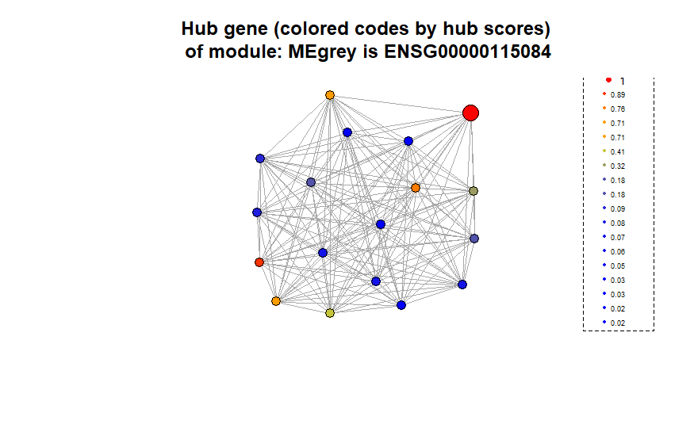

```r
  # Add a legend for node color
legend("bottomright", legend = round((hub_s$vector[top_nodes_pos]),2),
       col = CRP(50)[round(50*(hub_s$vector[top_nodes_pos]))], pch = 19,cex = 3*hub_size[top_nodes_pos]/20,
       title = "Node Values", bg = "white", box.lty = 2)
```

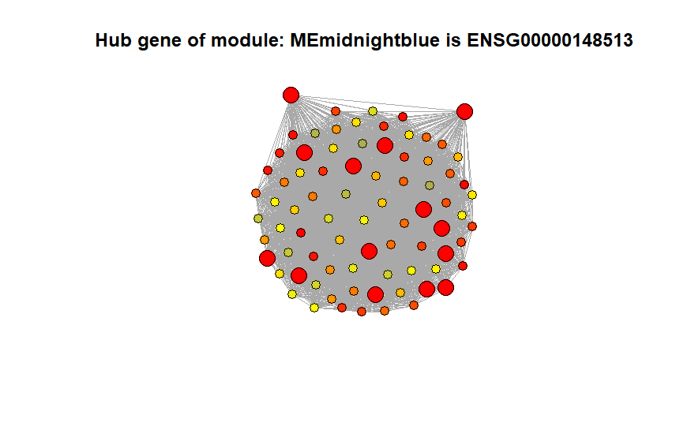

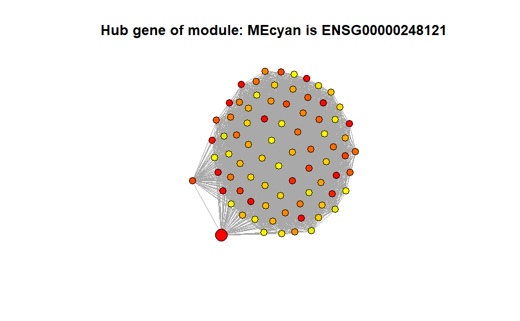

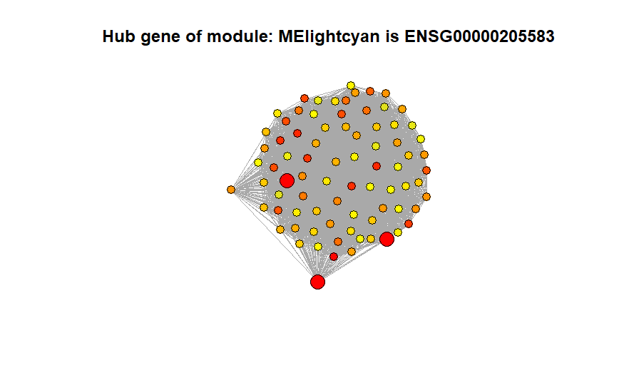

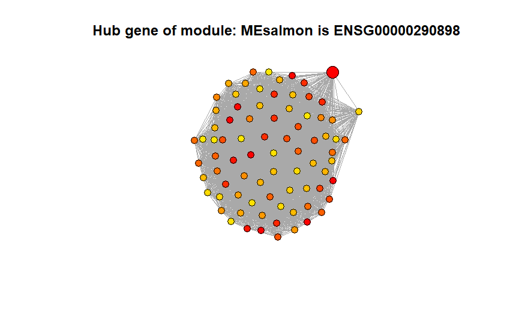

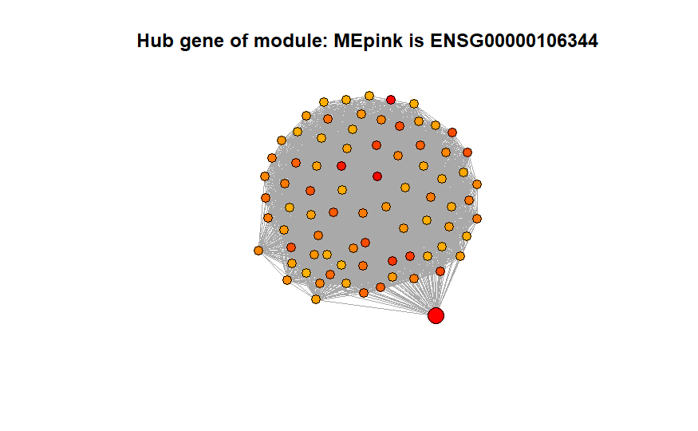

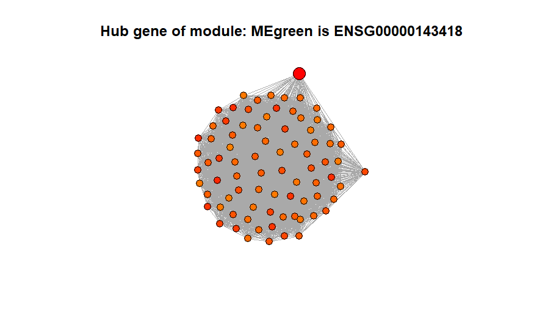

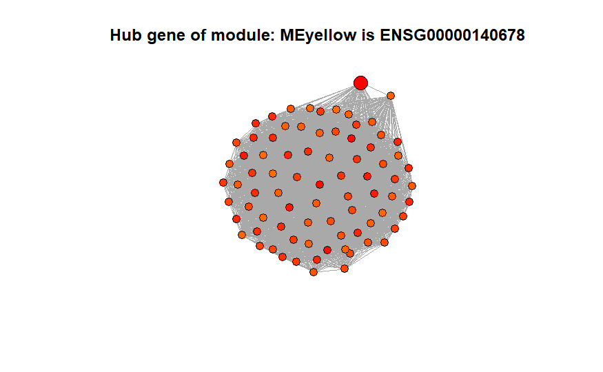

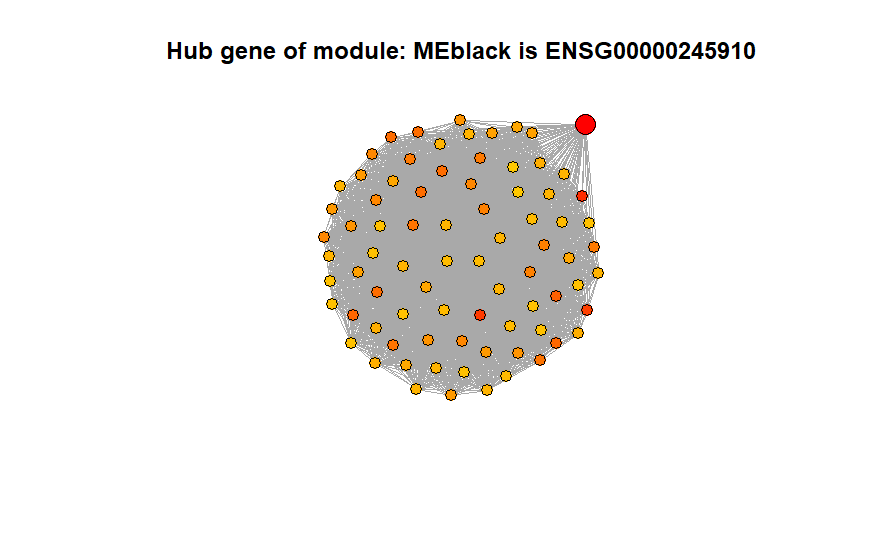

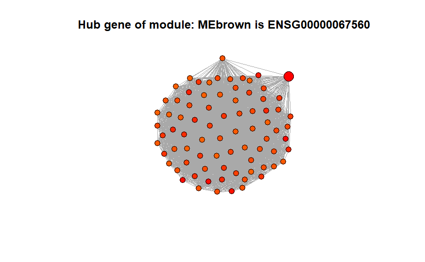

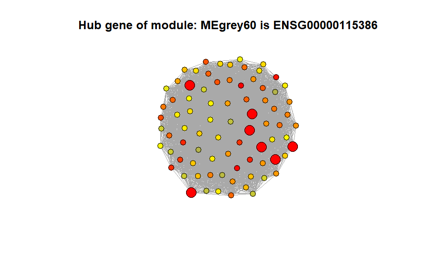

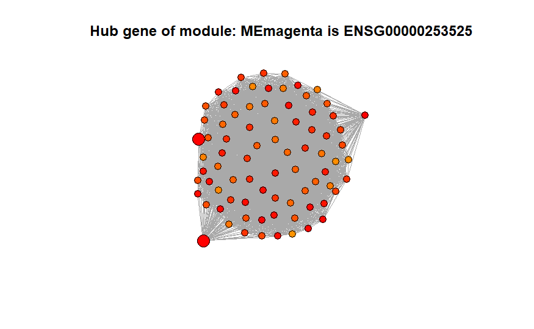

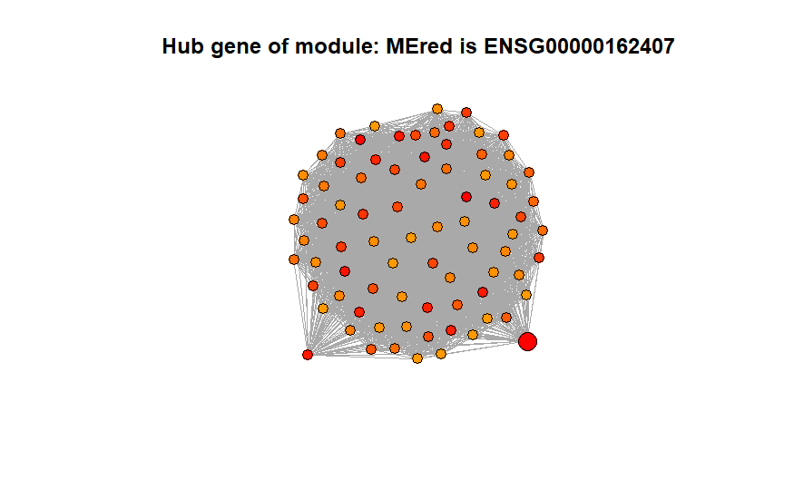

[6 more figures not shown]

```r
n0 = 80
# length(graph_list)
CRP = colorRampPalette(c("blue", "yellow", "red"))
for (i in c(1:length(graph_list))){
  hub_s <- hub_score(graph_list[[i]])
  hub_corlor <- rep("blue",length(hub_s$vector))
  hub_corlor[which(hub_s$vector == max(hub_s$vector))] <- "red"
  hub_size <- rep(3,length(hub_s$vector))
  hub_size[which(hub_s$vector == max(hub_s$vector))] <- 5
  hub_name <- rep(NA,length(hub_s$vector))
  hub_name[which(hub_s$vector == max(hub_s$vector))] <- names(hub_s$vector)[which(hub_s$vector == max(hub_s$vector))]

  top_nodes <- names((sort(hub_s$vector, decreasing = TRUE))[1:n0])

  top_nodes_pos <- find_pos_list(top_nodes, V(graph_list[[i]])$name)

  induce_graph <- subgraph(graph_list[[i]], vids = top_nodes_pos)


  coords <- layout_(induce_graph, with_lgl())
    plot(induce_graph, layout = coords, vertex.color = CRP(n0)[round(n0*(hub_s$vector[top_nodes_pos]))],vertex.label =NA,vertex.size=3*hub_size[top_nodes_pos], edge.width=0.01, color = "silver", shape = "sphere") + title(paste0("Hub gene of module: ",paste0("ME",list_color_modules[i])," is ",names(hub_s$vector)[which(hub_s$vector == max(hub_s$vector))[1]]) )

}
```

[figure not shown]

```r
NA
```

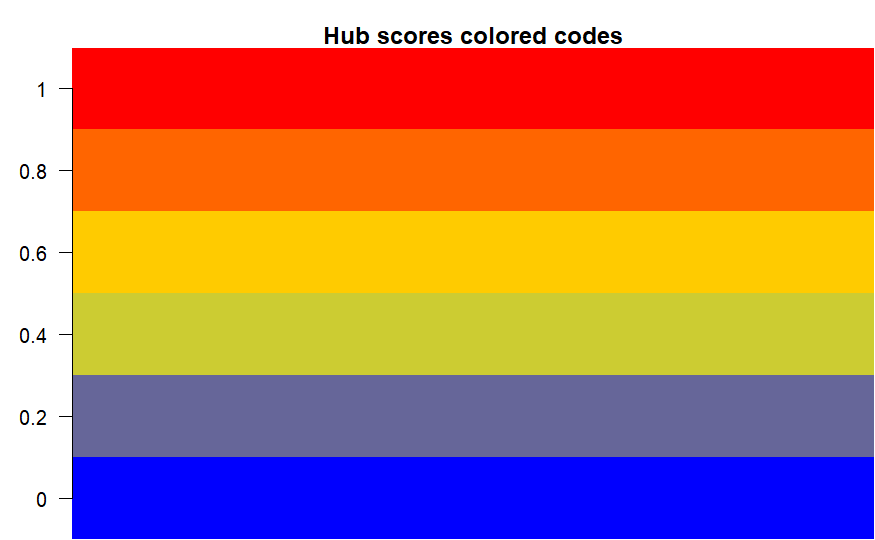

```r
# Define color palette
colors <- colorRampPalette(c("blue", "yellow", "red"))(length(seq(0,1,0.2)))

# Create a gradient legend
gradient_legend <- function(colors, values, title) {
  par(mar = c(0, 3, 2, 0))
  image(1, 1:length(colors), t(as.matrix(1:length(colors))),
        col = colors, axes = FALSE, xlab = "", ylab ="",xlim = c(1,1.2))
  axis(2, at = 1:length(colors), labels = values, las = 1)
  title(main = title, line = 0.2)
}

# Add the gradient legend
gradient_legend(colors, seq(0,1,0.2),"Hub scores colored codes")
```

# No need to run the following codes for your purpose now

```r
# calculate the module membership values (aka. module eigengene based
# connectivity kME):
datKME = signedKME(datExpr_filtered, MEs)
```

```r
GS.age = as.numeric(cor(datExpr_filtered, age, use = "p"))
# This translates the numeric values into colors
GS.ageColor = numbers2colors(GS.age, signed = T)

colorOfColumn = substring(names(datKME), 4)
par(mfrow = c(2, 2))
selectModules = colorOfColumn
par(mfrow = c(2, length(selectModules)/2))
for (module in selectModules) {
    column = match(module, colorOfColumn)
    restModule = colorOfColumn == module
    verboseScatterplot(datKME[restModule, column], GS.age[restModule], xlab = paste("Module Membership ",
        module, "module"), ylab = "GS.age", main = paste("kME.",
        "vs. GS"), col = module)
}
modTraitCor[,5]
```

# The following codes are for doing comparision between chosen groups. We can check if there are preserved modules (gene clusters) between 2 different groups, the differences of modules between them, etc.

## First we need to choose the groups we want to separate the data into groups

### Function to separate the data by chosen variable, design_traits has row names as library or samples

```r
groups_sep <- function(var_name, data, design_traits){

  # Make sure the order of samples are the same between data and trait design matrix

  design_traits = design_traits[rownames(data),]

  # Get all the possible values from the category

  list_data <- list()

  list_cat <- unique(design_traits[,var_name])
  i <- 1
  for (e in list_cat){
    list_data[[i]] = data[which(design_traits[,var_name] == e),]
    i = i+1
  }
  names(list_data) <- list_cat
  return(c(list_data,design_traits))
}
```

### Function to select sample from trait data design

```r
trait_dat[rownames(datExpr_filtered),]
```

```r
res_group <- groups_sep('condition',datExpr_filtered, trait_dat)
res_group[['control']]
```

# Now, we have data for a separate category of the chosen variable, we can do analysis on each of them

## Visualize the soft threshold to choose for the analysis

```r
# Choose a set of soft thresholding powers
powers = c(1:10)  # in practice this should include powers up to 20.
# choose power based on SFT criterion
sft = pickSoftThreshold(res_group[['control']], powerVector = powers,RsquaredCut = 0.7, nBreaks = 20, blockSize = 10000, networkType = "unsigned")

# change to

# sft=pickSoftThreshold(res_group[['control']],powerVector=powers, networkType = "signed")

# if want to do signed network
```

## Plot the graph to visualize the threshold to choose for finding similarity matrix A

```r
# Plot the results:
par(mfrow = c(1, 2))
# SFT index as a function of different powers
plot(sft$fitIndices[, 1], -sign(sft$fitIndices[, 3]) * sft$fitIndices[, 2],
    xlab = "Soft Threshold (power)", ylab = "SFT, signed R^2", type = "n", main = paste("Scale independence"))
text(sft$fitIndices[, 1], -sign(sft$fitIndices[, 3]) * sft$fitIndices[, 2],
    labels = powers, col = "red")
# this line corresponds to using an R^2 cut-off of h
abline(h = 0.9, col = "red")
# Mean connectivity as a function of different powers
plot(sft$fitIndices[, 1], sft$fitIndices[, 5], type = "n", xlab = "Soft Threshold (power)",
    ylab = "Mean Connectivity", main = paste("Mean connectivity"))
text(sft$fitIndices[, 1], sft$fitIndices[, 5], labels = powers, col = "red")
```

```r
# Default is unsign similarity, if you did with signed for threshold, need to change it to signed for adjacency option
A = adjacency(res_group[['control']], power = 6)
# Digression: to define a signed network choose A =
# adjacency(datExprFemale, power = 12, type='signed')

# define a dissimilarity based on the topological overlap
dissTOM = TOMdist(A)
```

### Get clusters by using hierarchical cluster model

```r
library(flashClust)
```

```r
# hierarchical clustering
geneTree = flashClust(as.dist(dissTOM), method = "average")
# here we define the modules by cutting branches
moduleLabelsManual = cutreeDynamic(dendro = geneTree, distM = dissTOM, method = "hybrid",
    deepSplit = 2, pamRespectsDendro = F, minClusterSize = 30)
```

## Next codes are for finding the Module (cluster) eigenvalues relationship with the traits of interest (example is age which is continuous variable)

```r
design_traits <- trait_dat
```

```r
# Calculate eigengenes
MEList = moduleEigengenes(res_group[['control']], colors = moduleColorsManual)
MEs = MEList$eigengenes

# Align the age from trait data to the MEs calculated
age <- design_traits$age
MET = orderMEs(cbind(MEs, age ))
# Plot the relationships among the eigengenes and the trait
plotEigengeneNetworks(MET, "", marDendro = c(0, 4, 1, 2), marHeatmap = c(3,
    4, 1, 2), cex.lab = 0.8, xLabelsAngle = 90)
```

## It is a good idea to merge clusters of genes that are highly correlated

```r
# automatically merge highly correlated modules

# mergingThresh: is maximal disimilarity threshold
mergingThresh <- 0.1 # default 0.2
merge = mergeCloseModules(res_group[['control']], moduleColorsManual, cutHeight = mergingThresh)
```

```r
age = as.data.frame(design_traits$age[1:3])
names(age) = "weight"
# Next use this trait to define a gene significance variable
GS.age = as.numeric(cor(res_group[['control']], age, use = "p"))
# This translates the numeric values into colors
GS.ageColor = numbers2colors(GS.age, signed = T)


# resulting merged module colors
moduleColorsManual_merge = merge$colors
# eigengenes of the newly merged modules:
MEsManual = merge$newMEs

# Show the effect of module merging by plotting the original and merged
# module colors below the tree
datColors = data.frame(moduleColorsManual_merge,
    GS.ageColor)
plotDendroAndColors(geneTree, colors = datColors, groupLabels = c("Module color",
     "GS.weight"), dendroLabels = FALSE, hang = 0.03,
    addGuide = TRUE, guideHang = 0.05)
```

```r
MEturquoise = sample(1:100,50)
MEblue      = sample(1:100,50)
MEbrown     = sample(1:100,50)
MEyellow    = sample(1:100,50)
MEgreen     = c(MEyellow[1:30], sample(1:100,20))
MEred       = c(MEbrown [1:20], sample(1:100,30))
MEblack     = c(MEblue  [1:25], sample(1:100,25))
ME     = data.frame(MEturquoise, MEblue, MEbrown, MEyellow, MEgreen, MEred, MEblack)
dat1   = simulateDatExpr(ME,300,c(0.2,0.1,0.08,0.051,0.05,0.042,0.041,0.3), signed=TRUE)
```

# References

1. Horvath, Steve. Weighted network analysis: applications in genomics and systems biology. Springer Science & Business Media, 2011.
2. Love, Michael I., Wolfgang Huber, and Simon Anders. “Moderated estimation of fold change and dispersion for RNA-seq data with DESeq2.” Genome biology 15.12 (2014): 1-21.
3. Csardi, Gabor, and Tamas Nepusz. “The igraph software package for complex network research.” InterJournal, complex systems 1695.5 (2006): 1-9.
4. Wu, Qibin, et al. “WGCNA identifies a comprehensive and dynamic gene co-expression network that associates with smut resistance in sugarcane.” International Journal of Molecular Sciences 23.18 (2022): 10770.
5. Xu, Yuexia, et al. “Identification of the Shared Gene Signatures between Autism Spectrum Disorder and Epilepsy via Bioinformatic Analysis.” Computational and Mathematical Methods in Medicine 2022 (2022).